# Avivo Demographics Markdown File

The purpose of this is provide some basic demographic data that was presented to Avivo on March 12,2018.

The sources are the custom made demographics data and the discharge portion of the Daanes file.

For the demographics data, I calculated age at time of the discharge. For race, I broke out the original race column and created 4 separate columns to make the data tidy (one variable per column). Please not that these are the number of unique patients as identified by Client.Number. Because there are clients with multiple visits, the number of patients is smaller than the number of visits.

Contents include:

- Previewing the data
- Counts by sex, primary race (race), and age grouping (age)
- Counts and percentages by age/sex, race/sex, age/race
- Success Rate by sex, race, and age
- Highest success rate by age/sex, race/sex, age/race

Accessing and setting up the data:

```r
demo <- read.csv("AvivoDemographicTablev3.csv",header = TRUE, sep=",")
library(data.table)
library(dplyr)
library(ggplot2)
opts_knit$set()
```

Previewing the data:

```r
dim(demo)
```

```
## [1] 1577   10
```

```r
summary(demo)
```

```
##    Client.Number    Date.of.Birth  Last.Discharge.Date Age.at.Discharge
##  10007    :   1   1/1/1984 :   3   10/28/2016:  10     Min.   :18.00
##  10023    :   1   1/1/1986 :   3   12/15/2017:  10     1st Qu.:30.00
##  10026    :   1   7/26/1989:   3   9/16/2016 :  10     Median :38.00
##  111155766:   1   1/1/1963 :   2   10/13/2017:   9     Mean   :38.52
##  111155768:   1   1/1/1989 :   2   12/18/2015:   9     3rd Qu.:47.00
##  111155775:   1   (Other)  :1380   2/10/2017 :   9     Max.   :71.00
##  (Other)  :1571   NA's     : 184   (Other)   :1520     NA's   :184
##       Sex                                    Race
##  Female :679   Black or African American       :633
##  Male   :712   White                           :370
##  Unknown:  2   American Indian or Alaska Native:145
##  NA's   :184   Other Race                      : 40
##                Declined to Specify             : 31
##                (Other)                         :134
##                NA's                            :224
##                               Race1
##  Black or African American       :666
##  White                           :418
##  American Indian or Alaska Native:162
##  Other Race                      : 40
##  Declined to Specify             : 31
##  (Other)                         : 36
##  NA's                            :224
##                                        Race2
##                                           :1478
##  American Indian or Alaska Native         :  30
##  Black or African American                :  18
##  Declined to Specify                      :  16
##  Hispanic or Latino                       :  22
##  Native Hawaiian or Other Pacific Islander:   4
##  Other Race                               :   9
##                                        Race3             Race4
##                                           :1565             :1576
##  American Indian or Alaska Native         :   4   Other Race:   1
##  Declined to Specify                      :   2
##  Hispanic or Latino                       :   4
##  Native Hawaiian or Other Pacific Islander:   1
##  Other Race                               :   1
##
```

```r
str(demo)
```

```
## 'data.frame':    1577 obs. of  10 variables:
##  $ Client.Number      : Factor w/ 1577 levels "10007","10023",..: 1530 1453 1454 1455 1456 1457 1458 1515 1516 1517 ...
##  $ Date.of.Birth      : Factor w/ 1325 levels "1/1/1955","1/1/1961",..: 190 1019 349 700 205 342 134 917 614 225 ...
##  $ Last.Discharge.Date: Factor w/ 628 levels "1/10/2016","1/11/2016",..: 134 480 6 300 117 468 68 197 596 410 ...
##  $ Age.at.Discharge   : int  44 47 56 54 40 54 50 63 62 55 ...
##  $ Sex                : Factor w/ 3 levels "Female","Male",..: 2 2 2 1 1 2 1 1 1 1 ...
##  $ Race               : Factor w/ 32 levels "American Indian or Alaska Native",..: 7 7 7 18 18 7 7 7 7 7 ...
##  $ Race1              : Factor w/ 8 levels "American Indian or Alaska Native",..: 3 3 3 8 8 3 3 3 3 3 ...
##  $ Race2              : Factor w/ 7 levels "","American Indian or Alaska Native",..: 1 1 1 1 1 1 1 1 1 1 ...
##  $ Race3              : Factor w/ 6 levels "","American Indian or Alaska Native",..: 1 1 1 1 1 1 1 1 1 1 ...
##  $ Race4              : Factor w/ 2 levels "","Other Race": 1 1 1 1 1 1 1 1 1 1 ...
```

**Count by Single Variable Graphs**

Count by sex graph:

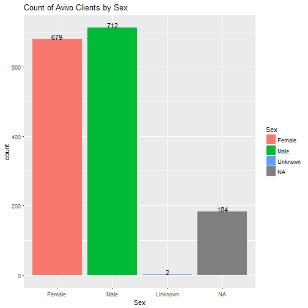

```r
ggplot(data=demo, aes(x=Sex)) +
     geom_bar(mapping= aes(fill=Sex)) +
     ggtitle("Count of Avivo Clients by Sex") +
     geom_text(stat='count',aes(label=..count..),vjust=0)
```

Fairly evenly divided between male and female. What is notable is the number of NAs (184 or 12%)

Count by primary race graph:

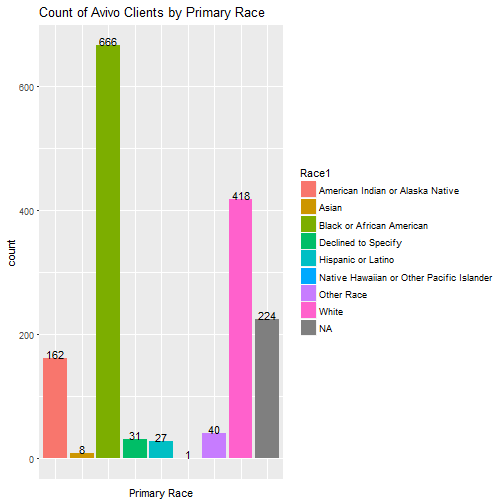

```r
ggplot(data=demo, aes(x=Race1)) +
     geom_bar(mapping= aes(fill=Race1)) +
     ggtitle("Count of Avivo Clients by Primary Race") +
     geom_text(stat='count',aes(label=..count..),vjust=0) +
     theme(axis.text.x=element_blank(),axis.ticks.x=element_blank()) +
     xlab("Primary Race")
```

Because race for demographic purposes is calculated by primary race, I broke the primary race by the first value in the race column from the Daanes file. African-Americans make up roughly half of the non-NA population, followed by patients who are White and then Native Americans. Hispanic or Latino and Asians appear in very small numbers.

For the age grouping, I grouped or cut the age by decade. This was done by changing the factor for age to numeric and using arbitrary cut points, but generally by decade.

```r
demo[3] <- lapply(demo[3], as.numeric)

demo$Age_group <- cut(demo$Age,
           breaks = c(-Inf, 30, 40, 50, 60, Inf),
           labels = c("Under 30", "30 to 39", "40 to 49", "50 to 59", "60+"),
           right = FALSE)
```

Count by age grouping graph:

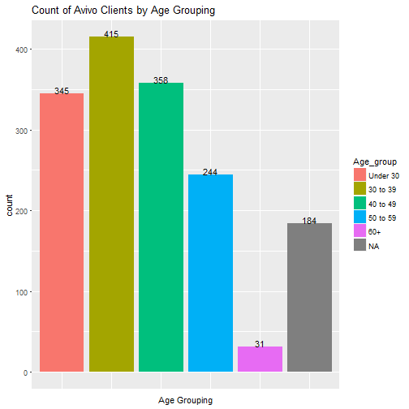

```r
ggplot(data=demo, aes(x=Age_group)) +
     geom_bar(mapping= aes(fill=Age_group)) +
     ggtitle("Count of Avivo Clients by Age Grouping") +
     geom_text(stat='count',aes(label=..count..),vjust=0) +
     theme(axis.text.x=element_blank(),axis.ticks.x=element_blank()) +
     xlab("Age Grouping")
```

The majority of the patients are between 18 and 49 years old. There is a drop in the 50-59 age range and then it drops significantly at 60.

**Count by 2 Variable Graphs**

With the 2 variable graphs, I need to explain how to read. The y-axis value are represented by the height of the bar. That was done to show scale. The value is the percentage within the x-axis variable.

Dataframe establishing count by age and sex:

```r
agesex <- demo %>%
    group_by(Age_group,Sex) %>%
    summarize(counts = n()) %>%
    mutate(percent_total = round(counts / sum(counts) * 100,1))
```

Count by age and sex graph:

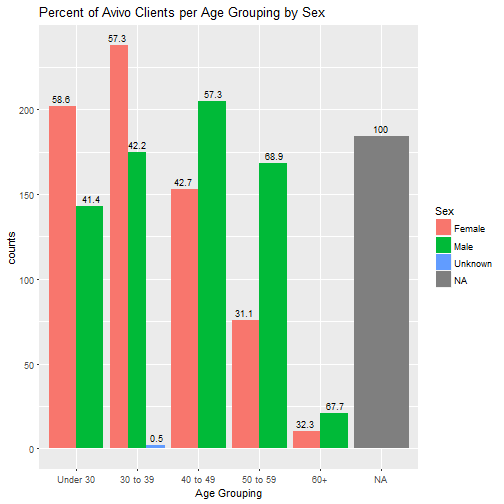

```r
ggplot(data=agesex, aes(x=Age_group, y=counts, fill=Sex))+
    geom_bar(stat="identity",position = 'dodge') +
    geom_text(aes(label=percent_total),color='black',position = position_dodge(width = 1), vjust = -0.5, size = 3) +
    ggtitle("Percent of Avivo Clients per Age Grouping by Sex")+
    xlab("Age Grouping")
```

Note that the younger patients skew more female while older patients skew more male.

dataframe establishing count by primary race and sex:

```r
primaryrace_sex <- demo %>%
    group_by(Race1,Sex) %>%
    summarize(counts = n()) %>%
    mutate(percent_total = round(counts / sum(counts) * 100,1))
```

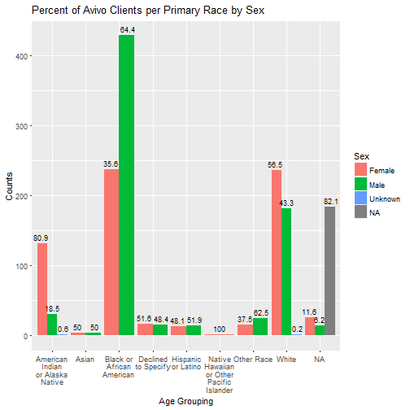

```r
library(stringr)
ggplot(data=primaryrace_sex, aes(x=Race1, y=counts, fill=Sex))+
    geom_bar(stat="identity",position = 'dodge') +
    geom_text(aes(label=percent_total),color='black',position = position_dodge(width = 1), vjust = -0.5, size = 3) +
    ggtitle("Percent of Avivo Clients per Primary Race by Sex")+
    xlab("Age Grouping") + ylab("Counts") +
    scale_x_discrete(labels = function(x) str_wrap(x, width = 10))
```

Almost 2/3 of the African-American patients are male, while over 80% of the Native American patients are female.

Dataframe establishing count by primary race and age group:

```r
primaryrace_agegroup <- demo %>%
group_by(Race1,Age_group) %>%
  summarize(counts = n()) %>%
  mutate(percent_total = round(counts / sum(counts) * 100,1))
```

Percent by race and age graph

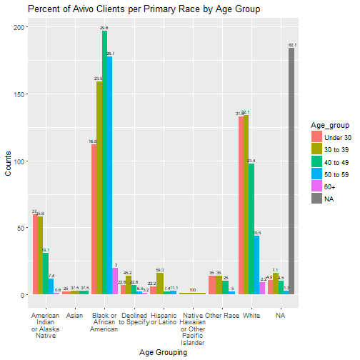

```r
ggplot(data=primaryrace_agegroup, aes(x=Race1, y=counts, fill=Age_group))+
  geom_bar(stat="identity",position = 'dodge') +
  geom_text(aes(label=percent_total),color='black',position = position_dodge(width = 1), vjust = -0.5, size = 2) +
  ggtitle("Percent of Avivo Clients per Primary Race by Age Group")+
  xlab("Age Grouping") + ylab("Counts") +
  scale_x_discrete(labels = function(x) str_wrap(x, width = 10))
```

What this shows is that American American patient shew older and Native American and White patient skew younger.

**Success by single demographic variable graphs**

Before getting into these graphs, the count now shifts from the number of patients to the number of visits. As a result the demographic and discharge data needs to be merged.

Taking only the discharge data because it this point it the same as the admission data and then merging it with the demographic data:

```r
avivo <- read.csv("admission_discharge_demographic.csv")
avivo_disc <- subset(avivo, avivo$Form.Flag == "discharge")
avivo_disc_demo <- merge(avivo_disc, demo, by="Client.Number")
```

Setting up variable indicating completion for Completed/Transferred:

```r
avivo_disc_demo$Completed_Program <- 0
avivo_disc_demo$Completed_Program <- ifelse (avivo_disc_demo$Reason.for.Discharge %in% c("Completed program","Transferred to other program"), 1, 0)
avivo_disc_demo$Completed_Program <- as.factor(avivo_disc_demo$Completed_Program)
```

Thank you Abhishek.

Dataframe establishing success rate by sex (gender)

```r
df_success_sex <- avivo_disc_demo %>%
  group_by(Sex.y, Completed_Program) %>%
  summarize(counts = n()) %>%
  mutate(percent_total = round(counts / sum(counts) * 100,1))
```

Success Rate by sex graph:

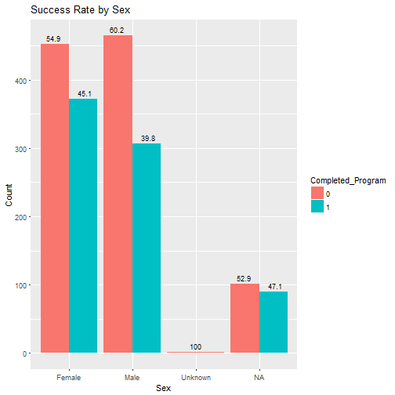

```r
ggplot(data = df_success_sex, aes(x = Sex.y, y = counts, fill = Completed_Program))+
  geom_bar(position = "dodge", stat = "identity") +
  geom_text(aes(label=percent_total),color='black',position = position_dodge(width = 1), vjust = -0.5, size = 3) +
  xlab("Sex") + ylab("Count") +
  ggtitle("Success Rate by Sex") +
  scale_x_discrete(labels = function(x) str_wrap(x, width = 10))
```

Females have a higher success rate than males. Note that the NA success rate is higher than both.

Dataframe establishing success rate by primary race:

```r
df_success_race<- avivo_disc_demo %>%
  group_by(Race1, Completed_Program) %>%
  summarize(counts = n()) %>%
  mutate(percent_total = round(counts / sum(counts) * 100,1))
```

Success rate by primary race graph:

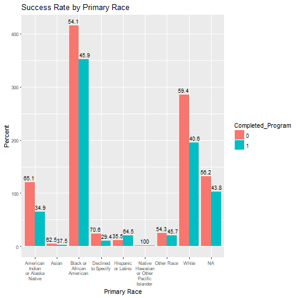

```r
ggplot(data = df_success_race, aes(x = Race1, y = counts, fill = Completed_Program))+
  geom_bar(position = "dodge", stat = "identity") +
  geom_text(aes(label=percent_total),color='black',position = position_dodge(width = 1), vjust = -0.5, size = 3) +
  xlab("Primary Race") + ylab("Percent") +
  ggtitle("Success Rate by Primary Race") +
  scale_x_discrete(labels = function(x) str_wrap(x, width = 10)) +
  theme(axis.text=element_text(size=8))
```

Dataframe establishing success rate by age group:

```r
df_success_age<- avivo_disc_demo %>%
  group_by(Age_group, Completed_Program) %>%
  summarize(counts = n()) %>%
  mutate(percent_total = round(counts / sum(counts) * 100,1))
```

Success rate by age group graph:

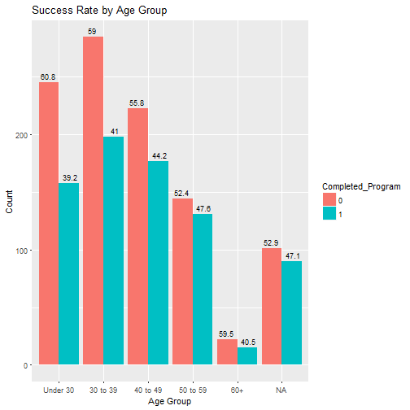

```r
ggplot(data = df_success_age, aes(x = Age_group, y = counts, fill = Completed_Program))+
  geom_bar(position = "dodge", stat = "identity") +
  geom_text(aes(label=percent_total),color='black',position = position_dodge(width = 1), vjust = -0.5, size = 3) +
  xlab("Age Group") + ylab("Count") +
  ggtitle("Success Rate by Age Group") +
  scale_x_discrete(labels = function(x) str_wrap(x, width = 10))
```

The success rate is higher as the age increases, except for 60+ aged clients.

**Success by 2 demographic variables graphs**

The part shows the success rate by 2 variables but rather than show all values, the highest are shown. Size is also not taken into account.

Dataframes establishing success rate by age group and sex:

```r
df_success_agesex <- avivo_disc_demo %>%
  group_by(Age_group, Sex.y, Completed_Program) %>%
  summarize(counts = n()) %>%
  mutate(percent_total = round(counts / sum(counts) * 100,1))

df_success_agesex$agesex <- paste(df_success_agesex$Age_group, df_success_agesex$Sex.y, sep="_")
```

Filtering out the unknowns:

```r
df_success_agesex_comp <- subset(df_success_agesex, Completed_Program == 1, Sex.y != "Unknown")
```

Success rate by age/sex group graph but only showing the success rate and ranked:

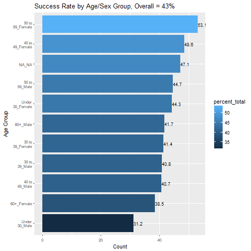

```r
ggplot(data = df_success_agesex_comp, aes(reorder(x = agesex,percent_total), y = percent_total, fill = percent_total))+
  geom_bar(position = "dodge", stat = "identity") +
  geom_text(aes(label=percent_total),color='black',position = position_dodge(width = 1), hjust = 0, size = 3) +
  xlab("Age Group") + ylab("Count") +
  ggtitle("Success Rate by Age/Sex Group, Overall = 43%") +
  coord_flip() +
  scale_x_discrete(labels = function(x) str_wrap(x, width = 10))+
  theme(axis.text=element_text(size=8))
```

Generally what is shows is that older patients are doing better. Younger and male appears to have the least likelihood of succeeding.

Dataframes establishing success rate by primary race and sex. Note that I filtered on the 3 primary races.

```r
df_success_racesex <- avivo_disc_demo %>%
  group_by(Race1, Sex.y, Completed_Program) %>%
  filter(Race1 %in% c("American Indian or Alaska Native","Black or African American","White")) %>%
  summarize(counts = n()) %>%
  mutate(percent_total = round(counts / sum(counts) * 100,1))

df_success_racesex$racesex <- paste(df_success_racesex$Race1, df_success_racesex$Sex.y, sep="_")
```

Filtering out the unknowns:

```r
df_success_racesex_comp <- subset(df_success_racesex, Completed_Program == 1, Sex.y != "Unknown")
```

Success rate by primary race/sex graph but only showing the success rate and ranked:

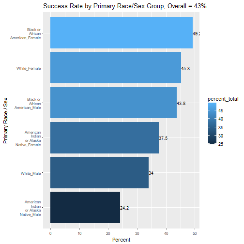

```r
ggplot(data = df_success_racesex_comp, aes(reorder(x = racesex,percent_total), y = percent_total, fill = percent_total))+
  geom_bar(position = "dodge", stat = "identity") +
  geom_text(aes(label=percent_total),color='black',position = position_dodge(width = 1), hjust = 0, size = 3) +
  xlab("Primary Race / Sex") + ylab("Percent") +
  ggtitle("Success Rate by Primary Race/Sex Group, Overall = 43%") +
  coord_flip() +
  scale_x_discrete(labels = function(x) str_wrap(x, width = 10))+
  theme(axis.text=element_text(size=8))
```

African American females have the highest success rates. Native American males have the lowest rates.

```r
df_success_raceage <- avivo_disc_demo %>%
  group_by(Race1, Age_group, Completed_Program) %>%
  filter(Race1 %in% c("American Indian or Alaska Native","Black or African American","White")) %>%
  summarize(counts = n()) %>%
  mutate(percent_total = round(counts / sum(counts) * 100,1))

df_success_raceage$raceage <- paste(df_success_raceage$Race1, df_success_raceage$Age_group, sep="_")

df_success_raceage_comp <- subset(df_success_raceage, Completed_Program == 1)
```

Success rate by primary race/age group graph but only showing the success rate and ranked:

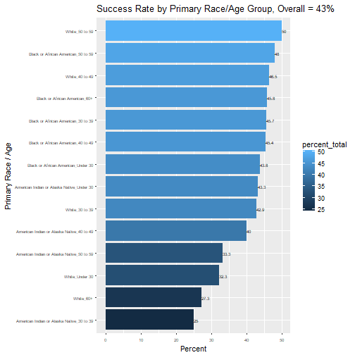

```r
ggplot(data = df_success_raceage_comp, aes(reorder(x = raceage,percent_total), y = percent_total, fill = percent_total))+
  geom_bar(position = "dodge", stat = "identity") +
  geom_text(aes(label=percent_total),color='black',position = position_dodge(width = 1), hjust = 0, size = 2) +
  xlab("Primary Race / Age") + ylab("Percent") +
  ggtitle("Success Rate by Primary Race/Age Group, Overall = 43%") +
  coord_flip() +
  theme(axis.text=element_text(size=6))
```

After the presentation with Avivo, the next steps are to break down the age groups starting with 18 to 26 and then figuring out the other age groups and to analyze 3 factor groupings. An example would be African American, Female, and Under 30.